# Supporting Data-Intensive Research in the Environmental Sciences

October 26, 2018

## Outline

- Study Motivation
- Research Questions
- Pilot Study & Faculty Interviews
- Study Design for Workshops
- Data Collection & Analysis
- Benefits of Research

## A Motivating Vignette

- Suppose you are an Ecology graduate student studying the abundance of wild and hatchery-raised pallid sturgeon. You have collected data over the last 2 years on fish abundance along the same reaches of the Missouri River, to look for trends in fish abundance.
- When recording your data in Excel, you chose for each section of the Missouri to be a row and every sampling instance to be a different column.

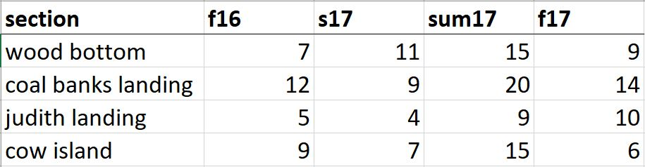

## Data Problems

The `R` functions you saw in your courses require for your data to be in long format.

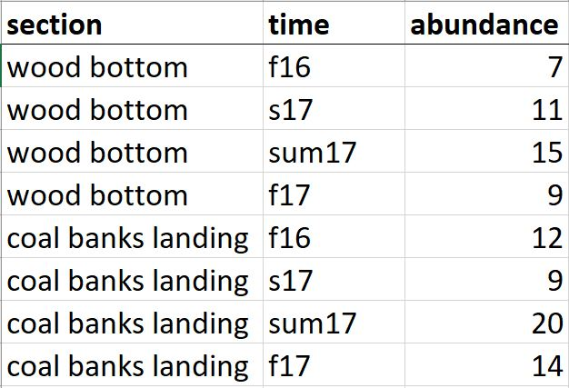

## Motivation

- Changing practice of environmental science has changed, because of growth in computational power and the volume and variety of available data.
- These advances have created a growing need for scientists to receive an appropriate education in computational methods and techniques relevant to their discipline.
- The growing need for computation in science education is greater than ever (Fox & Ouellette, 2013).

## (Lack of) Computing in Environmental Sciences

- In this rapidly changing computational landscape calls have surfaced to re-evaluate how curricula to "better prepare current and future generations of environmental researchers" (Green et al., 2005; Hampton et al., 2016).
- Over the last twenty years, Statistics preparation in the environmental sciences has become vital.
  - Hence, Statistics courses have been incorporated into these graduate programs, across the nation.

## (Lack of) Computing in Environmental Sciences

- A 2012 survey of graduate students:
  - over 80% of students reported that they had received no formal training in computing, even at the most basic level
  - 74% stated that they had no skills in any programming language (Hernandez, Meyernik, Murphy-Mariscal & Allen, 2012).
- And most, if not all of what is known about data management, visualization, and analysis has been learned piecemeal, or not learned at all (Teal et al., 2015).

## Why Aren't They Learning Computing?

- "What we teach [in Statistics] lags decades behind what we practice" and "the gap between our half-century-old curriculum and our contemporary statistical practice continues to widen" (Cobb, 2015).
- "Computing has been one of the most glaring omissions in the set of tools that have so far defined Statistics education" (Friedman, 2001).
- In our courses, do students build the confidence needed to overcome computational challenges?

## What Do We Teach?

- "Most of our students are not prepared for data analysis after their statistics [courses]," because "they have done very little actual data analysis" (Nolan & Temple Lang, 2010).
- Lumley (2015) stated that our students know how to deal with \(n \to \infty\) but cannot deal with a million observations.
- Students are either "told to learn how to program by themselves, from each other, or from their teaching assistant in a two-week "crash course" at the start of a course."
  - Sends a signal to students that computing is not of intellectual importance (Nolan & Temple Lang, 2010)

## Barriers to Incorporating Computing

- Attempting to fit more material into already-full courses and curricula.
- Potentially taught by people who may not feel prepared teach these topics.
- Not clear what computing should be included and how.
- Not all institutions have the flexibility to develop a statistics course on computing with data.

## Computational Knowledge Acquisition

- Most researchers "learn what they know about programming and data management on their own or the information is passed down within a lab" (Teal et al., 2015).
- This process potentially results in substantial hidden costs:
  - students pick up bad habits and misunderstandings
  - learn just enough to get through
  - initial knowledge severely limits them

## The Lens of Distributed Cognition

- Investigates the organization of cognitive systems but differs substantially from traditional cognitive theory.

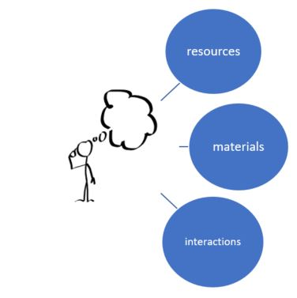

## Research Questions

1. What computing skills are necessary for environmental science graduate students to successfully implement applications of statistics in their research?
2. How are students filling the gap between the computing skills they know and the computing skills they need to know, in order to perform applications of statistics in their research?
3. How can workshops help to alleviate this gap between statistical computing preparation and expectations?

## Pilot Study (Spring 2017)

- In my pilot study I asked environmental science graduate students to complete applications of statistical computing, in the context of ecological data.

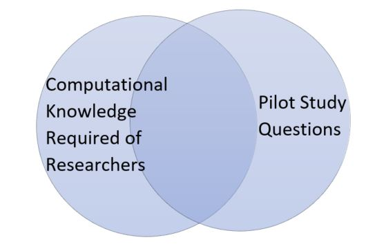

## Paths for Acquisition of Statistical Computing Skills

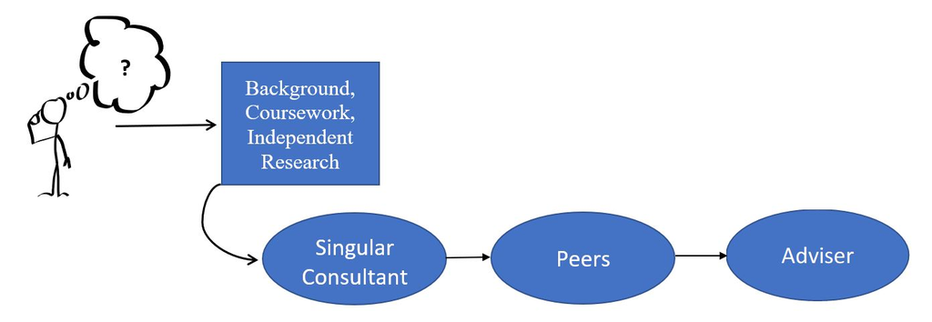

## Faculty Interviews (Spring 2018)

- Montana State faculty attributed these gaps in students' computational preparation, to the computational curricula at a university being driven by its faculty.
  - *"Most graduate students come in knowing more about the tools one would use to manipulate data than their advisors do, at this point."*
  - *"I think the expectations have gone up in order of magnitude in the last decade. We have very high expectations of statistics and very low expectations in computation."*
  - *"We had a computer science Python course that I took my first semester in grad school. That semester, I realized that [computing] was where biology was going."*

## Gaps in Computational Preparation

- Few "low-level" computational understandings were gained from their Statistics coursework.
  - *"By the end of the semester I wouldn't look at what the code was doing, I would just run it."*
  - *"I had to learn the R first and then I could look back at the code and understand what was going on."*
- Understandings informed by a student's independent research, were described largely as "high-level" concepts.
  - *"The data management stuff comes from independent research, trial and error, getting myself through."*
- **Proposed Solution:** workshops to develop computing skills

## Computing Learning Trajectory

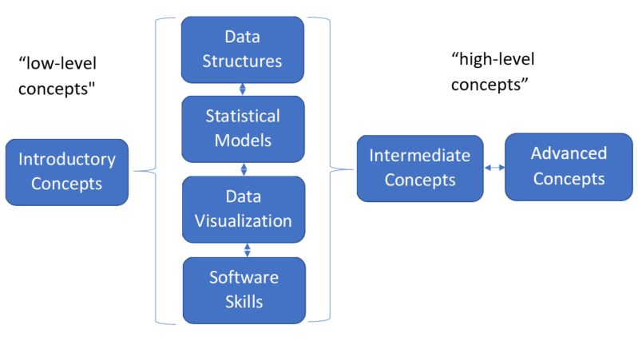

- "Instead of learning some things here and there, programming is a skill that is learned by building new information on top of earlier information" (Fuller et al., 2007).

## Classroom (Workshop) Design Study

- Systematically study the development of computational skills, in the context of environmental science research.
- Designing a means by which to support the development of these computational skills.
  - Investigate how to support this learning.
  - Develop, test, and revise conjectures about the learning process and how to support that learning.
- A design study is appropriate because:
  - it is difficult to study the learning of computing skills by observation
  - current research does not formulate what computational skills are necessary and how to teach them

## Components of a Design Study

- Specify goals for students' learning
- Document workshop starting points
- Delineate an envisioned learning trajectory
- Place the study in a theoretical context
- Iterate between workshop design, data collection, and analysis

## Workshop Learning Goals

- Unreasonable to expect that every researcher is an expert in their domain science, Statistics, data management, processing, and visualization (Hampton et al., 2015, p. 547).

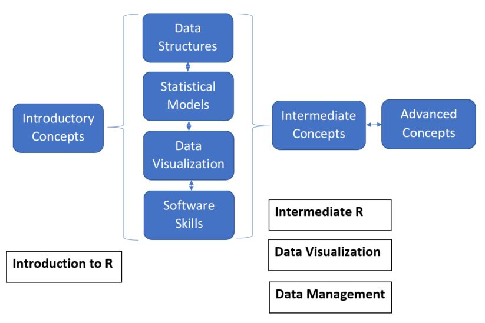

## Workshop Structure - Starting Points

- In the pilot study, as students reasoned through computational problems, their misconceptions of foundational concepts became unveiled.
- **Example:** Many misunderstandings revolved around how `R` interprets logicals (TRUE/FALSE).
  - *"Using the subset command where you call the data fame and you have your [], and just do -c(species = c("Bull", "WCT"))."*
  - *"I think you can remove observations by putting the observation number, but I don't know exactly how."*
  - *"I didn't know that was what was going on [subset using logicals]. I don't know if I was ever taught that."*

## Workshop Material - Starting Points

- Montana State faculty from environmental science fields were interviewed regarding the computational expectations they believed were necessary for Master's and Doctoral research in their field.
- Computational expectations varied across fields of research, however, many faculty emphasized:
  - writing functions
  - using conditional statements
  - looping & vectorization
  - database storage
  - data manipulation

## Computational Skills Data Collection

- A "control" cohort of first year environmental science graduate students were recruited in Spring 2018 to follow through their program of study.
  - None of the students participated in a workshop.
  - Code generated for research practices.
  - Interviews on acquisition of computational skills.
- Observations of common environmental science courses which teach computing (e.g. STAT 511, WILD 401, PSPP 516).
  - Collection of associated course materials (syllabi, labs, online resources).

## (Holistic) Workshop Data Collection

- Prior to the workshop, participants are surveyed for:
  - demographic information
  - what they expect and want to learn
  - what resources they have used to learn statistical computing
  - baseline knowledge
- Additionally, participants are asked to:
  - provide responses to "hands-on" applications of computational tasks
  - evaluate workshop effectiveness
- Workshops will be video recorded.

## (Intervention) Workshop Data Collection

- An "intervention" cohort of first year graduate students will be recruited in spring 2019.
  - Attend all four workshops in spring 2019.
  - Interview prior to first workshop, for baseline computational knowledge.
  - Interview following each workshop, to evaluate workshop environment, content, and map student learning.
  - Collect and analyze the code generated for research practices.
  - Interviews to investigate acquisition of computational skills.

## Analytical Framework (Computing Skills)

- Code generated for research for both cohorts will be coded to detail
  - skills used within each key area
  - progression of skills over time
- Course materials will be analyzed to isolate
  - computing concepts taught
  - instructional context used
- Course observations will be analyzed to describe
  - nature of classroom discourse
  - pedagogical methods of instruction

## Analytical Framework (Workshops)

- Workshop materials will be kept from their first implementation (fall 2017), to identify
  - evolution of workshop materials and learning environment over the duration of the study
  - how these changes supported students' development of successive forms of reasoning
- Workshop recordings and interviews with "intervention" cohort will be open coded to detail
  - how successive forms of reasoning emerged as a reorganization of prior reasoning
  - aspects of the workshop environment that helped promote learning
  - how workshops impacted students' preparation for statistical computing in their research

## Benefits to Environmental Science Research

- Outline key computational skills necessary for successful implementation of statistics to research in the environmental sciences.
- Detail the paths that students employ when faced with computational challenges for their research.
- Understanding the importance of core skills for data-intensive environmental science research will help "facilitate the integration of training into the university" (Hampton et al., 2015, p. 555).

## Benefits for Environmental Science *Researchers*

- The materials developed through these workshops will be publicly available.
- Create new resources to enhance students' learning of core computational skills.
- Introductory workshops have no barriers to entry.
- Workshops build off of knowledge acquired in previous workshops, without additional knowledge expectations.

## Benefits to Curriculum

- Help to ease transition to integrating computing into the environmental science and Statistics curricula.
  - Pooling of resources.
  - Materials are available in formats which can be quickly adapted and customized.

## Many Thanks

- Stacey Hancock
- Megan Wickstrom & Mary Alice Carlson
- Jenny Green, Laura Hildreth, Megan Higgs, Beth Burroughs
- Workshop Facilitators!

## References

http://rpubs.com/atheobold/proposal

## Questions?

## Does Computing Belong in Statistics?

- Despite the urging of the discipline to incorporate computing into the curriculum, members of the discipline remain skeptical of the reformation of statistics curriculum.
- Moore (1997) cautioned statisticians to remember that we are "teaching our subject and not the tool" (p. 135).
- De Veaux & Vellman (2015) suggest that we "should not allow debates about methods to distract us from teaching a holistic understanding of what statisticians actually do."
- However, many practitioners argue that we should give our students the skills needed to "dive into the ocean."
  - "We cannot be paralyzed by the potential dangers, as students will go swimming with or without us, and all we can do is prepare them as best we are able" (Wickam, 2015).

## Faculty Preparation

- "How do we prepare current faculty, the vast majority of whom were taught in the probabilistic culture, to develop courses that teach skills from both cultures?" (Peck, Chance, Rossman, 2015).
- Our community needs to engage seriously in the preparation of teachers, not just through hosting workshops, but through changing teacher preparation at the undergraduate, graduate, and credentialing levels.
  - Both science and math teachers are, with some exceptions, frightfully unprepared to teach students to engage meaningfully with data (Gould, 2015).

## Faculty Preparation (continued)

- One challenge to the success of this change is that statisticians often have not been taught computing formally, they have not had the opportunity to learn it well, and feel they cannot teach it effectively, and so the cycle persists.
  - This is very unfortunate as it means that new students do not have the opportunity to learn it well either.
  - Computing has become so much more important in the statistics field and a "just enough" level of understanding of computing is not adequate.

## What Do We Teach

- **Learning Outcomes**:
  - demonstrate a basic understanding of using statistical software to perform data analysis
  - demonstrate a basic understanding of using computer software to investigate statistical concepts through simulation
- **Course Goals**:
  - translate the output from statistical software into appropriate and meaningful results

## Not Consistent Across Semesters

- **Learning Outcomes for Lab**:
  - Write code compliant with style conventions, with annotation
  - Use basic logic (&, |, ifelse, !, etc.) and indexing
  - Write for-loops, while statements, and with statements
  - Identify processes that can be broken off into discrete functions
  - Design and write functions, including appropriate tests
  - Test for and correct simple bugs in a for-loop or function
  - Conduct basic data aggregation and cleaning
  - Design and construct effective data visualizations
  - Conduct all statistical analyses presented in lecture

## Tenants of Distributed Cognition

- Cognitive processes involve trajectories of information, the patterns of these trajectories reflects some underlying cognitive architecture.
- The organization of mind, both in development and in operation, is an emergent property of interactions among internal and external resources.
- The study of cognition is not separable from the study of culture, because agents live in complex cultural environments. (Hollan, Hutchins, & Kirsh, 2000).

## Connection to Distributed Cognition

- No method other than observation can illuminate "what matters" in a setting.
- As the design process creates new tools for individuals, it adds new cognitive interactions to the study.
  - Iterative process of observation to theory to design suggested for research in distributed cognition.

## Spiralizing Bloom's Taxonomy

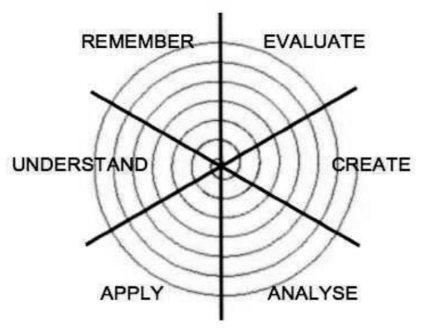

- The spiral approach sees "each round as thoroughly learning some new piece of information which is then used as a basis for the next round in the topic" (Fuller et al., 2007).

## Interpretive Framework

- We are focusing on workshop tasks and tools, the nature of field norms, and the quality of workshop discourse as potential supports for student learning.
- Forms of computational reasoning adults develop are shaped by
  - the settings of their learning
  - by the collective practices they participate in while learning (Hall, 2001; Hoyles, Noss, Pozzi, 2001).

## Theoretical Context

- Places the study in a larger theoretical context, as a case of supporting students' development of the statistical computing skills necessary for research.
  - Discovery of fundamental computing skills required.
  - Understanding of effective teaching techniques to promote the learning of these skills.
- Create a "humble theory," upon which generalizations could potentially be based.

## Workshops Analytical Model

| Stage | Time Period |
| --- | --- |
| Memo & Reflection | day of workshop |
| Attentively view video data | week of workshop |
| Identifying critical events | week of workshop |
| Transcribing | April 2019 |
| Coding | May - June 2019 |
| Constructing storyline | July - August 2019 |
| Composing narrative | Fall 2019 |